# Harpur Enrollment and Add-Drop Analysis

Dave Clark

Friday, September 25, 2026

## Most of the change over three Fall semesters is at the 100 level

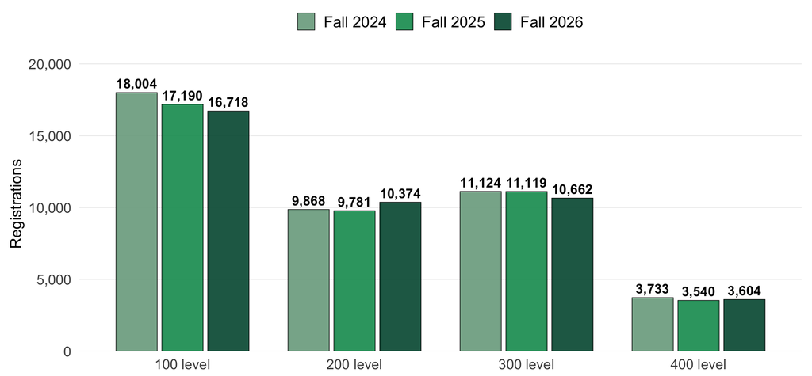

## Registrations by division

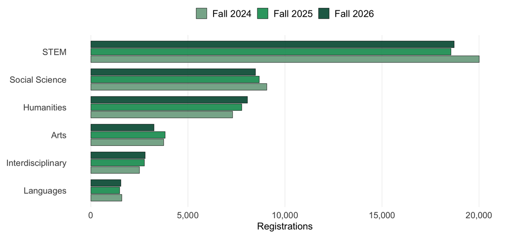

## Department change, Fall 2024 → Fall 2025

Departments with at least 50 registrations in Fall 2024 or Fall 2026.

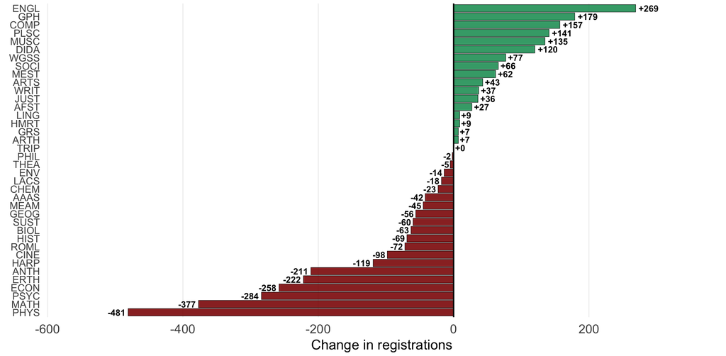

## Department change, Fall 2025 → Fall 2026

Departments with at least 50 registrations in Fall 2024 or Fall 2026.

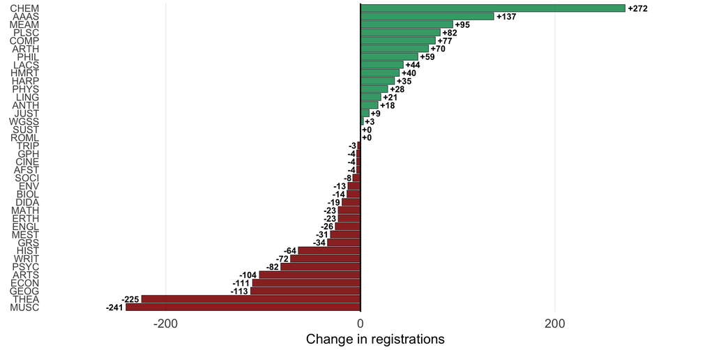

## Two different years, not one trend

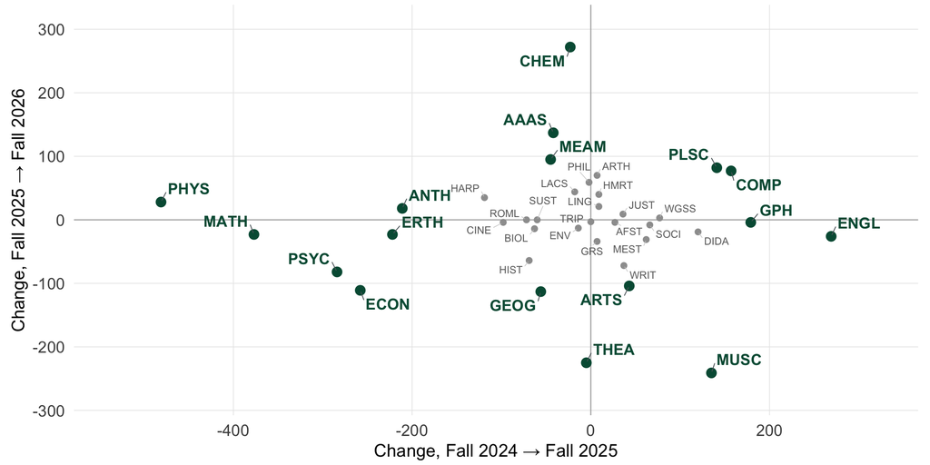

## AP credit has doubled

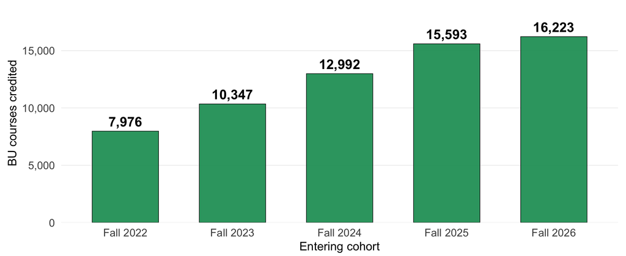

All colleges — the summary sheet’s Fall 2026 column. It counts **course credits granted**, one per student per exam per BU course. Nine in ten exams credit one course, so 16,223 credits came from 14,273 exams; the gap is calculus and biology, where one exam credits several courses (eg, a Calculus BC exam credits MATH 224, 225, 226 and an elective).

## Each student brings more of it

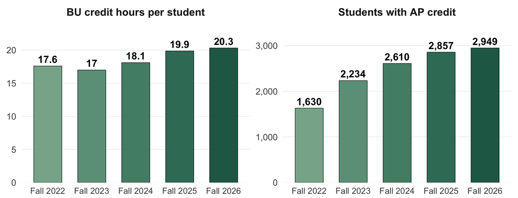

## What students are getting credit for

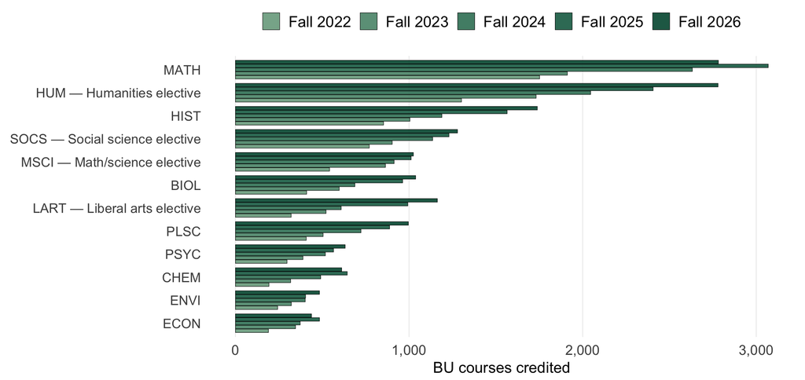

**HUM** humanities elective, **SOCS** social science elective, **MSCI** math/science elective, **LART** liberal arts elective. All four are Harpur requirements.

# Add-Drop Analysis

## Add-Drop Behavior in Harpur College

- **What.** Add/drop behavior in Harpur College over **9 semesters, Fall 2022 through Fall 2026** — 312,228 Banner transactions.
- **Focus on Fall 2026.** The pattern barely moves term to term, so nearly every slide shows **Fall 2026**; the last slide shows all nine semesters. Adds-drops completed by the fifth class day range only from 70.1% to 75.2% across those semesters.
- **Who.** Harpur students, in every course they take including non-Harpur courses.
- **Counting.** Banner records a row per *section*, so one course with a lecture, discussion and lab records three sections. Those collapse to one **event**: one student, one course, one direction, one day.
- **Days are class days**, not calendar days; everything before the first class meeting is pooled as “before classes.”

## Add/drop events by day — Fall 2026

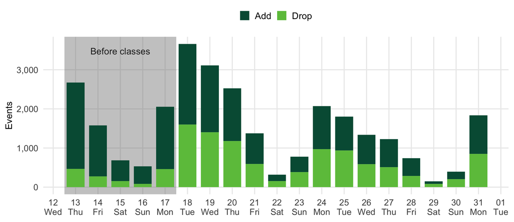

## Cumulative share of events — Fall 2026

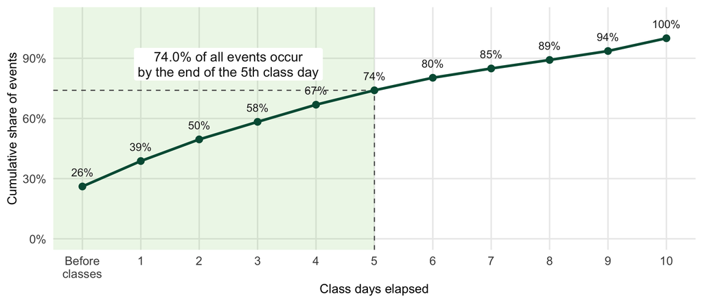

## Adds and drops — Fall 2026

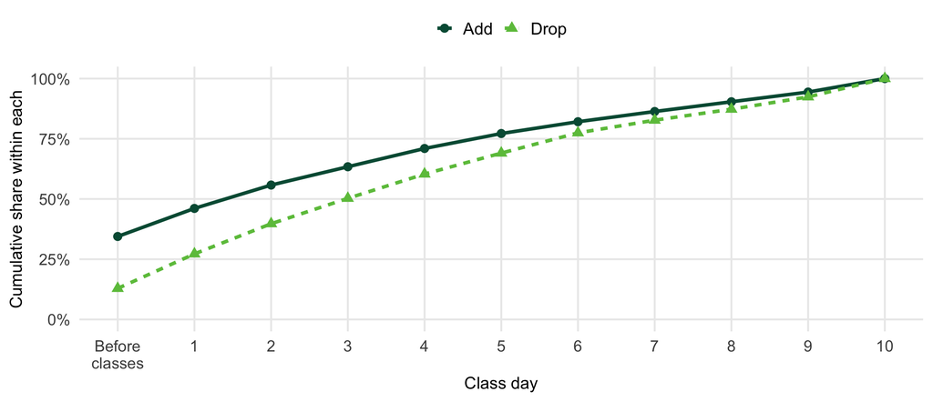

## Section swaps — Fall 2026

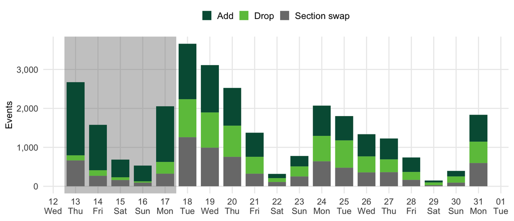

## By student level — Fall 2026

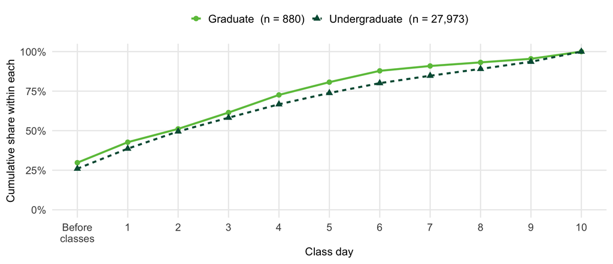

## By residency — Fall 2026

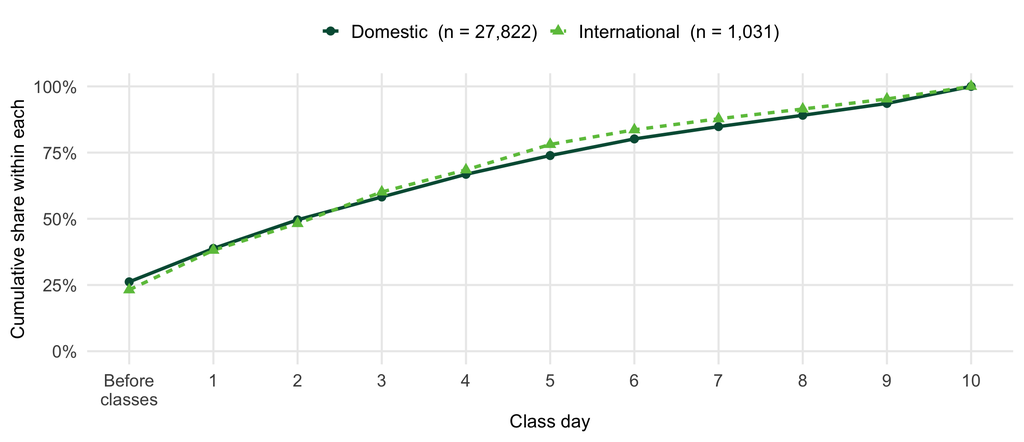

## By divisional field of the course — Fall 2026

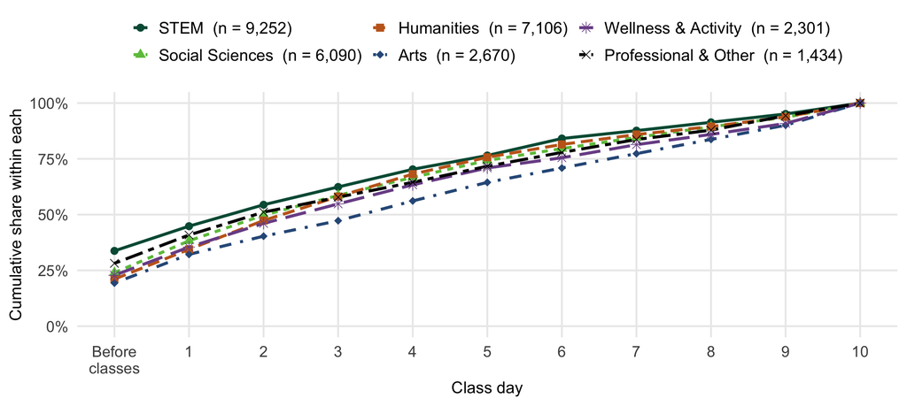

## First-year students — Fall 2026

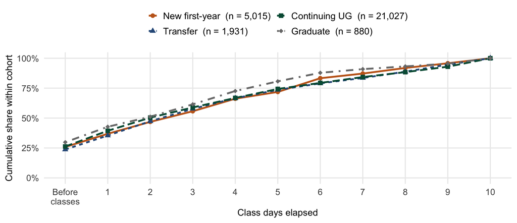

## First-year students — adds per drop, five fall terms

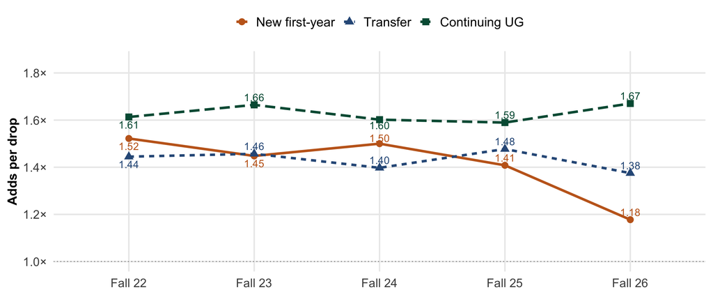

## Waitlist conversion by day — Fall 2026

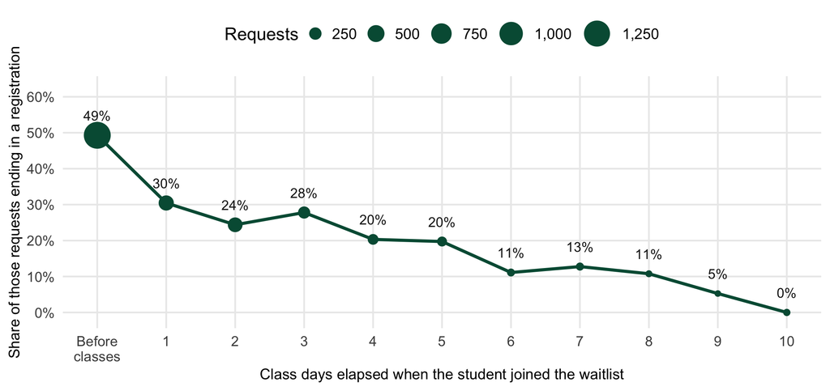

## Waitlist requests by when they were placed — Fall 2026

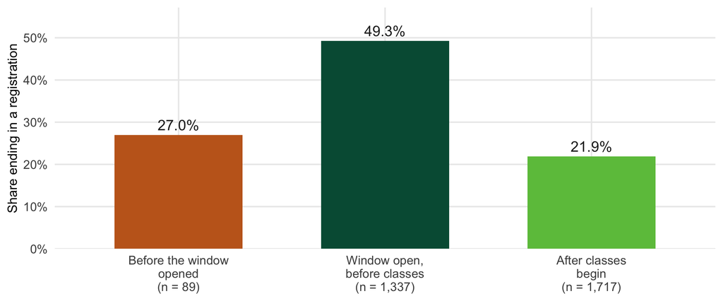

## Waitlist conversion by subject — nine semesters pooled

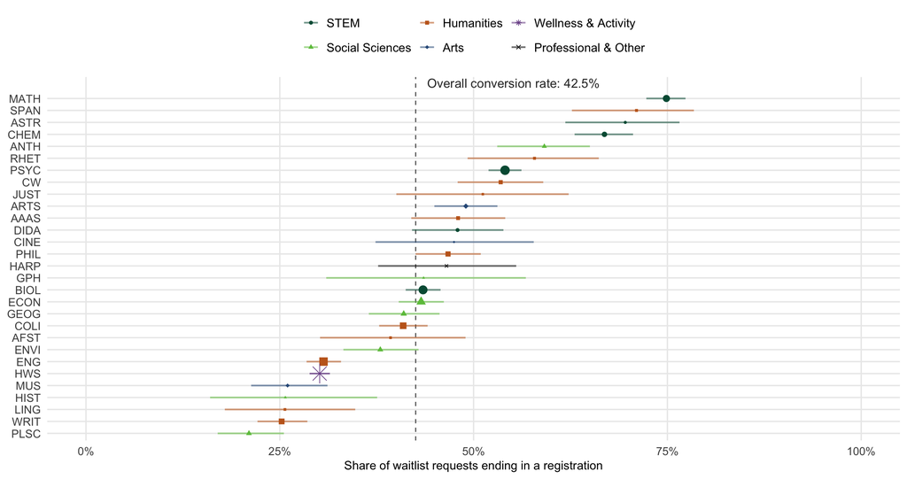

## Waitlist demand and conversion over time

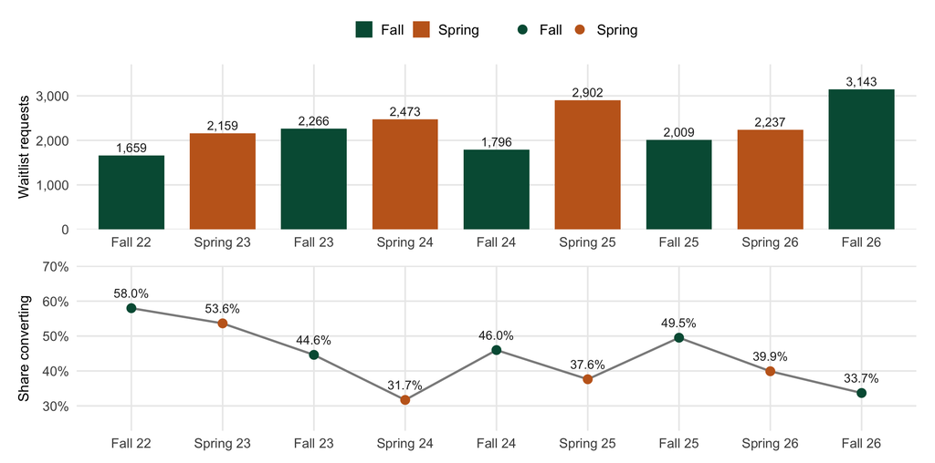

## Add-Drop events Fall 2022 - Fall 2026

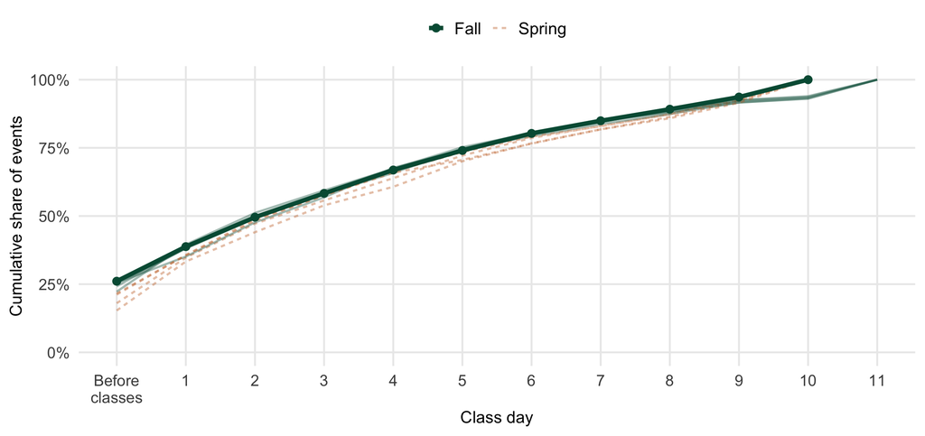